# Session 2: Homework 1

Kasia Gasiewska

2020-10-18

# 1 Where Do People Drink The Most Beer, Wine And Spirits?

Back in 2014, [fivethiryeight.com](https://fivethirtyeight.com/features/dear-mona-followup-where-do-people-drink-the-most-beer-wine-and-spirits/) published an article on alchohol consumption in different countries.

```r
library(fivethirtyeight)
data(drinks)
```

We have one column with character data which contains country names and four columns with numerical data which contains the amount of each type of alcohol consumed in these countries. There are no missing variables.

```r
glimpse(drinks)
```

```
## Rows: 193
## Columns: 5
## $ country                      <chr> "Afghanistan", "Albania", "Algeria", "An…
## $ beer_servings                <int> 0, 89, 25, 245, 217, 102, 193, 21, 261, …
## $ spirit_servings              <int> 0, 132, 0, 138, 57, 128, 25, 179, 72, 75…
## $ wine_servings                <int> 0, 54, 14, 312, 45, 45, 221, 11, 212, 19…
## $ total_litres_of_pure_alcohol <dbl> 0.0, 4.9, 0.7, 12.4, 5.9, 4.9, 8.3, 3.8,…
```

```r
skim(drinks)
```

Data summary

| Name | drinks |
| --- | --- |
| Number of rows | 193 |
| Number of columns | 5 |
| _______________________ |  |
| Column type frequency: |  |
| character | 1 |
| numeric | 4 |
| ________________________ |  |
| Group variables | None |

**Variable type: character**

| skim_variable | n_missing | complete_rate | min | max | empty | n_unique | whitespace |
| --- | --- | --- | --- | --- | --- | --- | --- |
| country | 0 | 1 | 3 | 28 | 0 | 193 | 0 |

**Variable type: numeric**

| skim_variable | n_missing | complete_rate | mean | sd | p0 | p25 | p50 | p75 | p100 | hist |
| --- | --- | --- | --- | --- | --- | --- | --- | --- | --- | --- |
| beer_servings | 0 | 1 | 106.16 | 101.14 | 0 | 20.0 | 76.0 | 188.0 | 376.0 | ▇▃▂▂▁ |
| spirit_servings | 0 | 1 | 80.99 | 88.28 | 0 | 4.0 | 56.0 | 128.0 | 438.0 | ▇▃▂▁▁ |
| wine_servings | 0 | 1 | 49.45 | 79.70 | 0 | 1.0 | 8.0 | 59.0 | 370.0 | ▇▁▁▁▁ |
| total_litres_of_pure_alcohol | 0 | 1 | 4.72 | 3.77 | 0 | 1.3 | 4.2 | 7.2 | 14.4 | ▇▃▅▃▁ |

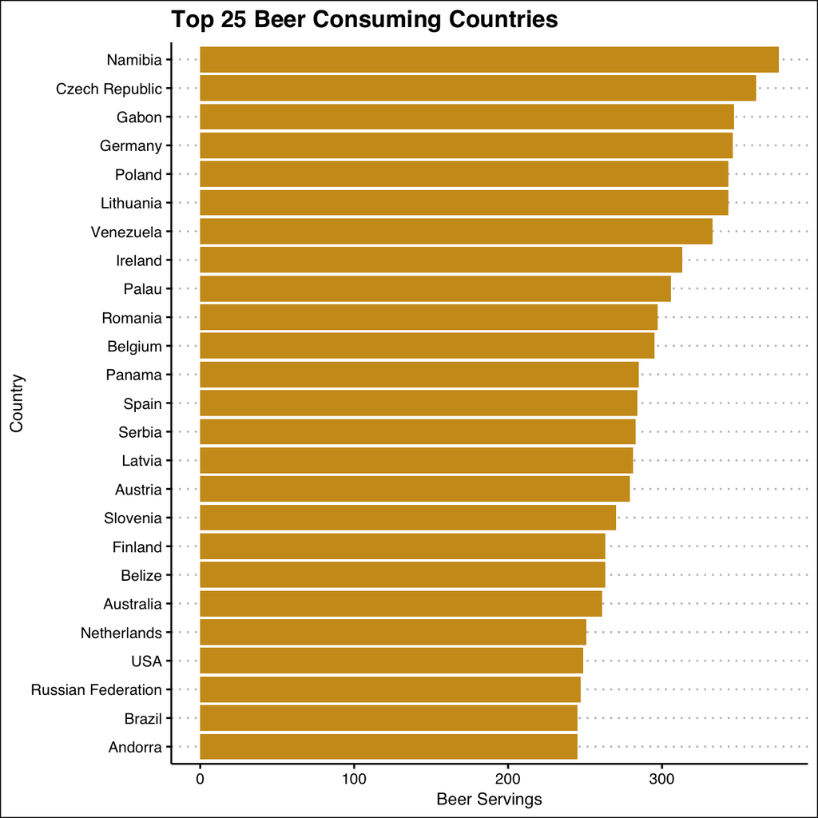

```r
desc_beer <- drinks %>%
  arrange(desc(beer_servings))

top25_beer <- head (desc_beer, 25)

ggplot(top25_beer,
       aes(x = reorder (country, beer_servings),
           y = beer_servings)) +
      geom_col(fill = "goldenrod3") +
      labs(x = "Country",
           y = "Beer Servings",
           title="Top 25 Beer Consuming Countries") +
      coord_flip() +
      theme_clean() +
           NULL
```

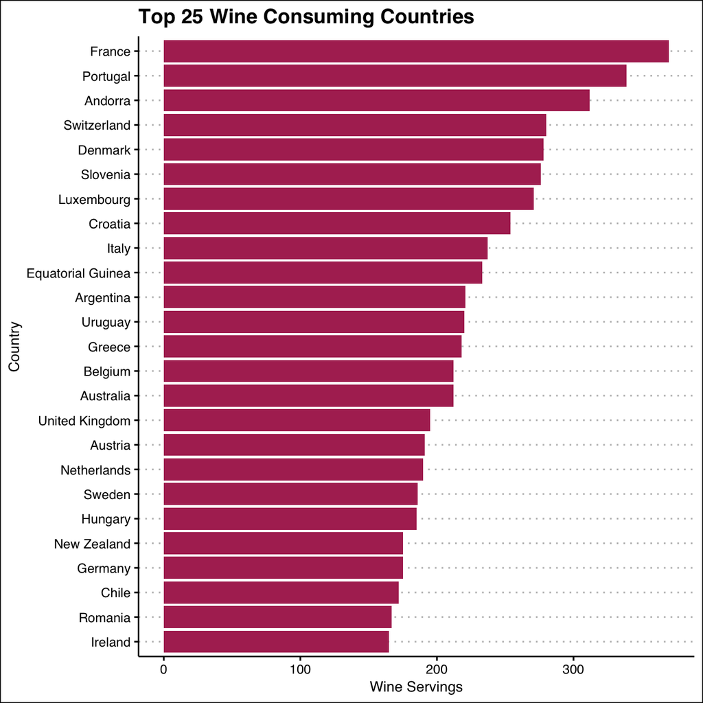

```r
desc_wine <- drinks %>%
  arrange(desc(wine_servings))

top25_wine <- head (desc_wine, 25)

ggplot(top25_wine,
       aes(x=reorder (country, wine_servings),
           y=wine_servings)) +
  geom_col(fill = "maroon") +
  labs(x = "Country",
       y = "Wine Servings",
       title = "Top 25 Wine Consuming Countries") +
  coord_flip() +
  theme_clean() +
  NULL
```

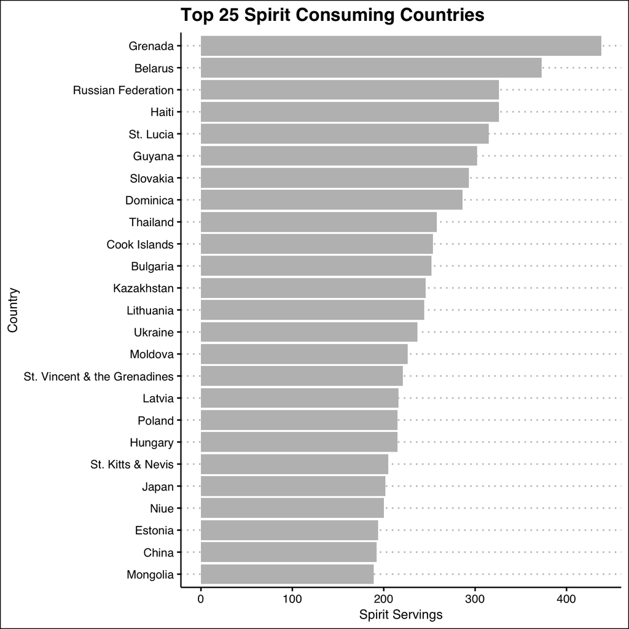

```r
desc_spirit <- drinks %>%
  arrange( desc(spirit_servings) )

top25_spirit <- head(desc_spirit,25)

ggplot (top25_spirit,
        aes(x = reorder(country, spirit_servings),
            y = spirit_servings)) +
  geom_col(fill="grey") +
  labs(x = "Country",
       y="Spirit Servings",
       title="Top 25 Spirit Consuming Countries") +
  coord_flip() +
  theme_clean() +
  NULL
```

> In the first plot we can see that Namibia has the highest yearly consumption of beer per capita. Beer is one of Namibia’s most iconic commodity and their top quality brewing is a legacy of German colonialism.The second most beer-loving country is Czech Republic, known for its unique brewing methods and prevalent drinking culture.

> The second plot, representing wine consumption, shows that French and Portugese drink the most wine. It is not very suprising given these are one of the most well known wine producing countries in the world.

> Last but not least, looking at the third plot we can see that Grenada and Belarus are the most spirit-loving countries. We can safely assume that Grenadians prefer to drink rum while Belarusians enjoy their vodka.